# Example 8: matching using MatchIt

## Matching

Greedy algorithm, covariate balancing is not satisfying

```r
## Greedy algorithm
m.out1 <- matchit(treat ~ age + educ + race + married +
                   nodegree + re74 + re75, data = lalonde,
                  estimand = "ATT",
                 method = "nearest", distance = lps)
summary(m.out1)
```

```
Call:
matchit(formula = treat ~ age + educ + race + married + nodegree +
    re74 + re75, data = lalonde, method = "nearest", distance = lps,
    estimand = "ATT")

Summary of Balance for All Data:
           Means Treated Means Control Std. Mean Diff. Var. Ratio eCDF Mean
distance          0.2121       -1.8606          1.8456     0.6082    0.3534
age              25.4463       26.9167         -0.2103     0.4537    0.0748
educ             10.3220       10.2366          0.0417     0.5423    0.0291
raceblack         0.8362        0.2339          1.6272          .    0.6023
racehispan        0.0621        0.1640         -0.4218          .    0.1018
racewhite         0.1017        0.6022         -1.6558          .    0.5005
married           0.1977        0.4382         -0.6037          .    0.2404
nodegree          0.6949        0.6290          0.1431          .    0.0659
re74           2179.3904     4051.3213         -0.3760     0.8686    0.1692
re75           1485.9177     2329.2386         -0.2622     0.9815    0.1236
           eCDF Max
distance     0.6074
age          0.1413
educ         0.0837
raceblack    0.6023
racehispan   0.1018
racewhite    0.5005
married      0.2404
nodegree     0.0659
re74         0.4022
re75         0.2685


Summary of Balance for Matched Data:
           Means Treated Means Control Std. Mean Diff. Var. Ratio eCDF Mean
distance          0.2121       -0.7040          0.8158     0.7784    0.1285
age              25.4463       25.2316          0.0307     0.4336    0.0870
educ             10.3220       10.5876         -0.1294     0.6076    0.0235
raceblack         0.8362        0.4915          0.9311          .    0.3446
racehispan        0.0621        0.2203         -0.6553          .    0.1582
racewhite         0.1017        0.2881         -0.6168          .    0.1864
married           0.1977        0.2090         -0.0284          .    0.0113
nodegree          0.6949        0.6384          0.1227          .    0.0565
```

[output cut: 18 more lines]

```
educ                -210.7       18.6      19.3     19.0
raceblack             42.8          .      42.8     42.8
racehispan           -55.3          .     -55.3    -55.3
racewhite             62.7          .      62.7     62.7
married               95.3          .      95.3     95.3
nodegree              14.2          .      14.2     14.2
re74                  91.0     -115.6      71.7     36.8
re75                  85.0    -2032.9      59.1     24.2

Sample Sizes:
          Control Treated
All           372     177
Matched       177     177
Unmatched     195       0
Discarded       0       0
```

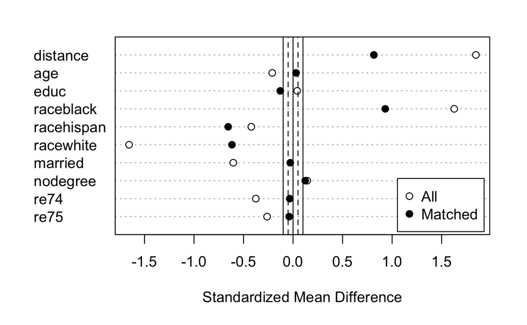

```r
plot(summary(m.out1), abs = F)
```

- We change to optimal matching, and covariate balancing is still not satisfying

```r
## Optimal matching algorithm
## install additional package
##install.packages("optmatch") and choose the binary version
library("optmatch")
m.out2 <- matchit(treat ~ age + educ + race + married +
                   nodegree + re74 + re75, data = lalonde,
                  estimand = "ATT",
                 method = "optimal", distance = lps)
summary(m.out2)
```

```
Call:
matchit(formula = treat ~ age + educ + race + married + nodegree +
    re74 + re75, data = lalonde, method = "optimal", distance = lps,
    estimand = "ATT")

Summary of Balance for All Data:
           Means Treated Means Control Std. Mean Diff. Var. Ratio eCDF Mean
distance          0.2121       -1.8606          1.8456     0.6082    0.3534
age              25.4463       26.9167         -0.2103     0.4537    0.0748
educ             10.3220       10.2366          0.0417     0.5423    0.0291
raceblack         0.8362        0.2339          1.6272          .    0.6023
racehispan        0.0621        0.1640         -0.4218          .    0.1018
racewhite         0.1017        0.6022         -1.6558          .    0.5005
married           0.1977        0.4382         -0.6037          .    0.2404
nodegree          0.6949        0.6290          0.1431          .    0.0659
re74           2179.3904     4051.3213         -0.3760     0.8686    0.1692
re75           1485.9177     2329.2386         -0.2622     0.9815    0.1236
           eCDF Max
distance     0.6074
age          0.1413
educ         0.0837
raceblack    0.6023
racehispan   0.1018
racewhite    0.5005
married      0.2404
nodegree     0.0659
re74         0.4022
re75         0.2685


Summary of Balance for Matched Data:
           Means Treated Means Control Std. Mean Diff. Var. Ratio eCDF Mean
distance          0.2121       -0.7041          0.8158     0.7783    0.1285
age              25.4463       25.2316          0.0307     0.4336    0.0870
educ             10.3220       10.5876         -0.1294     0.6076    0.0235
raceblack         0.8362        0.4915          0.9311          .    0.3446
racehispan        0.0621        0.2203         -0.6553          .    0.1582
racewhite         0.1017        0.2881         -0.6168          .    0.1864
married           0.1977        0.2090         -0.0284          .    0.0113
nodegree          0.6949        0.6384          0.1227          .    0.0565
```

[output cut: 18 more lines]

```
educ                -210.7       18.6      19.3     19.0
raceblack             42.8          .      42.8     42.8
racehispan           -55.3          .     -55.3    -55.3
racewhite             62.7          .      62.7     62.7
married               95.3          .      95.3     95.3
nodegree              14.2          .      14.2     14.2
re74                  91.0     -115.6      71.7     36.8
re75                  85.1    -2031.2      59.2     24.2

Sample Sizes:
          Control Treated
All           372     177
Matched       177     177
Unmatched     195       0
Discarded       0       0
```

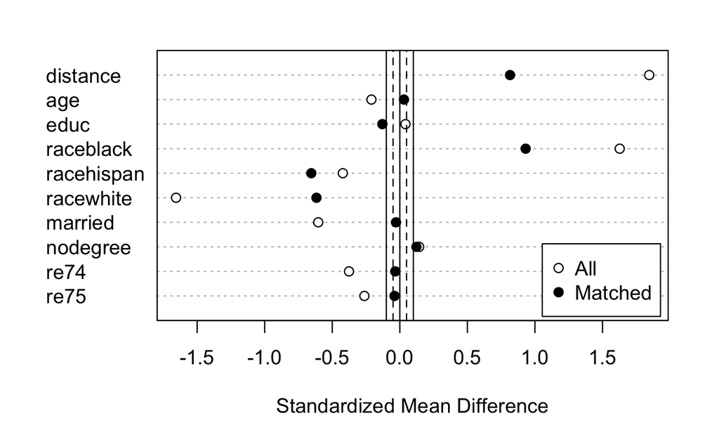

```r
plot(summary(m.out2), abs = F)
```

You see that even the linearized propensity score are not matched well, which indicates that some treated units are not able to be well matched (as there are not enough controls with lps > 0).

Three strategies to improve balancing:

- Strategy I: require exact match for race, as race seems to be the most unbalanced covariate and is discrete

```r
m.out3 <- matchit(treat ~ age + educ + race + married +
                   nodegree + re74 + re75, data = lalonde,
                  estimand = "ATT", exact = "race",
                 method = "optimal", distance = lps)
```

```
Fewer control units than treated units in some 'exact' strata; not all treated units will get a match.
```

```r
summary(m.out3)
```

```
Call:
matchit(formula = treat ~ age + educ + race + married + nodegree +
    re74 + re75, data = lalonde, method = "optimal", distance = lps,
    estimand = "ATT", exact = "race")

Summary of Balance for All Data:
           Means Treated Means Control Std. Mean Diff. Var. Ratio eCDF Mean
distance          0.2121       -1.8606          1.8456     0.6082    0.3534
age              25.4463       26.9167         -0.2103     0.4537    0.0748
educ             10.3220       10.2366          0.0417     0.5423    0.0291
raceblack         0.8362        0.2339          1.6272          .    0.6023
racehispan        0.0621        0.1640         -0.4218          .    0.1018
racewhite         0.1017        0.6022         -1.6558          .    0.5005
married           0.1977        0.4382         -0.6037          .    0.2404
nodegree          0.6949        0.6290          0.1431          .    0.0659
re74           2179.3904     4051.3213         -0.3760     0.8686    0.1692
re75           1485.9177     2329.2386         -0.2622     0.9815    0.1236
           eCDF Max
distance     0.6074
age          0.1413
educ         0.0837
raceblack    0.6023
racehispan   0.1018
racewhite    0.5005
married      0.2404
nodegree     0.0659
re74         0.4022
re75         0.2685


Summary of Balance for Matched Data:
           Means Treated Means Control Std. Mean Diff. Var. Ratio eCDF Mean
distance         -0.1307       -0.1576          0.0240     1.0094    0.0061
age              25.7414       26.1034         -0.0518     0.4951    0.0716
educ             10.1207       10.3793         -0.1261     0.6544    0.0254
raceblack         0.7500        0.7500          0.0000          .    0.0000
racehispan        0.0948        0.0948          0.0000          .    0.0000
racewhite         0.1552        0.1552          0.0000          .    0.0000
married           0.2414        0.2759         -0.0866          .    0.0345
nodegree          0.6724        0.6207          0.1123          .    0.0517
```

[output cut: 18 more lines]

```
educ                -202.6       30.7      12.7     17.6
raceblack            100.0          .     100.0    100.0
racehispan           100.0          .     100.0    100.0
racewhite            100.0          .     100.0    100.0
married               85.7          .      85.7     85.7
nodegree              21.5          .      21.5     21.5
re74                  85.6     -145.4      59.8     29.3
re75                  77.2    -2490.3      44.7     39.0

Sample Sizes:
          Control Treated
All           372     177
Matched       116     116
Unmatched     256      61
Discarded       0       0
```

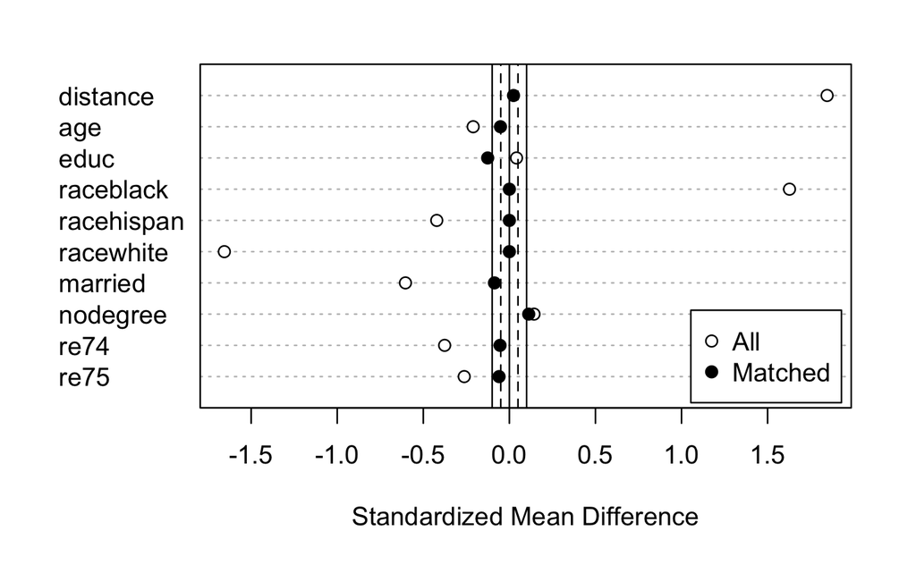

```r
plot(summary(m.out3), abs = F)
```

- Strategy II: we can to improve balancing by discard units if the distance between pairs are two large

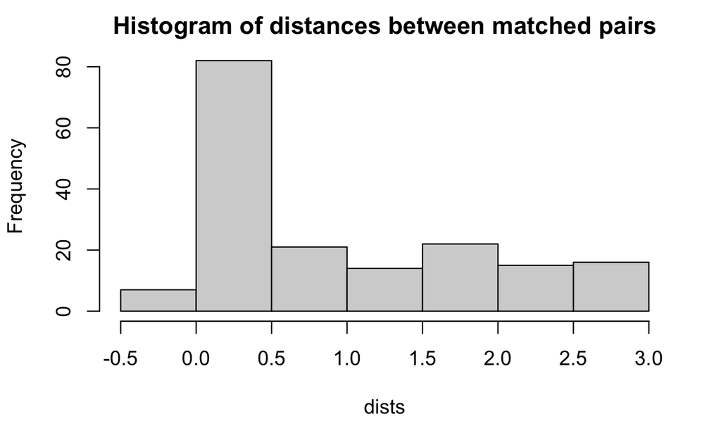

```r
names(lps) <- rownames(lalonde)
dists <- lps[rownames(m.out2$match.matrix)] - lps[m.out2$match.matrix[,1]]
hist(dists, main = "Histogram of distances between matched pairs")
```

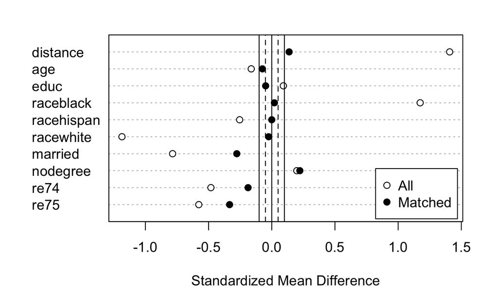

```r
## We see that some distances are large.

## We set a threshold 1 to make a balance between removing poor matches and retain most of the treated units
ID.treated.notmatched <- names(dists[abs(dists) > 1])
lalonde.new <- lalonde[!(rownames(lalonde) %in% ID.treated.notmatched),]
lps.new <- lps[!(rownames(lalonde) %in% ID.treated.notmatched)]

m.out4 <- matchit(treat ~ age + educ + race + married +
                   nodegree + re74 + re75, data = lalonde.new,
                  estimand = "ATT",
                 method = "optimal", distance = lps.new)
plot(summary(m.out4), abs = F)
```

```r
summary(m.out4)
```

```
Call:
matchit(formula = treat ~ age + educ + race + married + nodegree +
    re74 + re75, data = lalonde.new, method = "optimal", distance = lps.new,
    estimand = "ATT")

Summary of Balance for All Data:
           Means Treated Means Control Std. Mean Diff. Var. Ratio eCDF Mean
distance          0.0469       -1.8606          1.4078     0.8854    0.3314
age              25.8000       26.9167         -0.1626     0.4377    0.0772
educ             10.4091       10.2366          0.0919     0.4546    0.0367
raceblack         0.7455        0.2339          1.1744          .    0.5116
racehispan        0.0909        0.1640         -0.2542          .    0.0731
racewhite         0.1636        0.6022         -1.1853          .    0.4385
married           0.1545        0.4382         -0.7846          .    0.2836
nodegree          0.7182        0.6290          0.1982          .    0.0891
re74           1705.0367     4051.3213         -0.4815     0.8321    0.2130
re75           1083.5616     2329.2386         -0.5774     0.4417    0.1578
           eCDF Max
distance     0.5344
age          0.1518
educ         0.1147
raceblack    0.5116
racehispan   0.0731
racewhite    0.4385
married      0.2836
nodegree     0.0891
re74         0.4562
re75         0.3185


Summary of Balance for Matched Data:
           Means Treated Means Control Std. Mean Diff. Var. Ratio eCDF Mean
distance          0.0469       -0.1394          0.1374     1.1420    0.0393
age              25.8000       26.3091         -0.0741     0.3857    0.0945
educ             10.4091       10.5000         -0.0484     0.5131    0.0287
raceblack         0.7455        0.7364          0.0209          .    0.0091
racehispan        0.0909        0.0909          0.0000          .    0.0000
racewhite         0.1636        0.1727         -0.0246          .    0.0091
married           0.1545        0.2545         -0.2766          .    0.1000
nodegree          0.7182        0.6182          0.2223          .    0.1000
```

[output cut: 18 more lines]

```
educ                  47.3       15.4      21.7     12.8
raceblack             98.2          .      98.2     98.2
racehispan           100.0          .     100.0    100.0
racewhite             97.9          .      97.9     97.9
married               64.7          .      64.7     64.7
nodegree             -12.2          .     -12.2    -12.2
re74                  61.1       37.2      50.5     28.3
re75                  42.2       28.0      38.0     25.8

Sample Sizes:
          Control Treated
All           372     110
Matched       110     110
Unmatched     262       0
Discarded       0       0
```

Covariate balancing improves. However, notice that because we have removed more than 1/3 of of the treated units, the treated population may have changed dramastically. The ATT we estimate here can be biased for the ATT of the original population.

- Strategy III: In the software tutorial, it uses another method called “optimal full matching” and reaches extremely good balancing. It assigns every treated and control unit in the sample to one subclass each (Hansen 2004; Stuart and Green 2008). Each subclass contains one treated unit and one or more control units or one control units and one or more treated units. Here it performs better than optimal matching, as full matching allows one control be matched with many treated units.

We can also use matching with replacement here, which does a similar job.

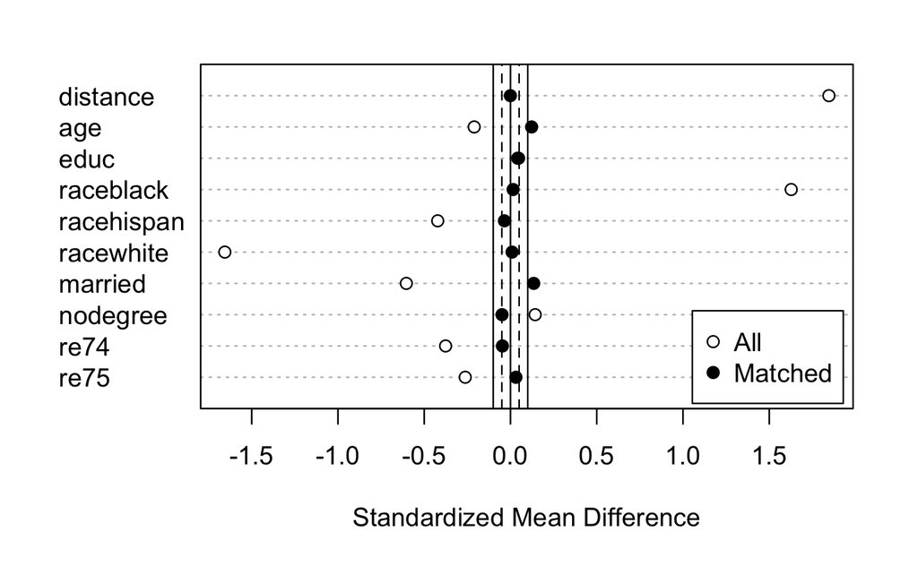

```r
## We match each treated with 2 controls to increase stability (as some controls may be used multiple times)
m.out5 <- matchit(treat ~ age + educ + race + married +
                   nodegree + re74 + re75, data = lalonde,
                  estimand = "ATT", replace= T, ratio = 2,
                 method = "nearest", distance = lps)
plot(summary(m.out5), abs = F)
```

## Estimate the ATT

We can continue with either m.out3 or m.out5.

- If we continue with m.out3:

```r
m.data <- match.data(m.out3)

## Neyman's approach, treating the data as from a pairwise randomized experiment
tau_hat_vec <- sapply(levels(m.data$subclass), function(sc) {
  treated <- m.data$re78[m.data$subclass == sc & m.data$treat == 1]
  control <- m.data$re78[m.data$subclass == sc & m.data$treat == 0]
  return(treated - control)
})

tau_hat <- mean(tau_hat_vec, na.rm = T)
sd_tau_hat <- sd(tau_hat_vec)/sqrt(length(tau_hat_vec))
print(c(tau_hat, sd_tau_hat))
```

```
[1] 1009.6593  861.6323
```

```r
## 95% CI
print(c(tau_hat- 1.96 * sd_tau_hat, tau_hat + 1.96 * sd_tau_hat))
```

```
[1] -679.1401 2698.4587
```

- Neyman’s approach with regression adjustment of the bias

```r
## First run a linear regression on the control (remember to remove the treatment assignment variable!)

fit0 <- lm(re78 ~ age + educ + race + married + nodegree +
             re74 + re75, data = m.data[m.data$treat == 0, ])

m.data$predicted_y0 <- predict(fit0, m.data)

## Neyman's approach with regression adjustment
tau_hat_vec_adjusted <- sapply(levels(m.data$subclass), function(sc) {
  treated <- m.data$re78[m.data$subclass == sc & m.data$treat == 1]
  control <- m.data$re78[m.data$subclass == sc & m.data$treat == 0]

  bias <- m.data$predicted_y0[m.data$subclass == sc & m.data$treat == 1] -
    m.data$predicted_y0[m.data$subclass == sc & m.data$treat == 0]
  control.adjusted <- control + bias

  return(treated - control.adjusted)
})

tau_hat_adjusted <- mean(tau_hat_vec_adjusted)
sd_tau_hat_adjusted <- sd(tau_hat_vec_adjusted)/sqrt(length(tau_hat_vec_adjusted))
print(c(tau_hat_adjusted, sd_tau_hat_adjusted))
```

```
[1] 1081.3067  847.2499
```

```r
## 95% CI
print(c(tau_hat_adjusted- 1.96 * sd_tau_hat_adjusted, tau_hat_adjusted + 1.96 * sd_tau_hat_adjusted))
```

```
[1] -579.3032 2741.9165
```

Run outcome regression directly:

```r
fit <- lm(re78 ~ treat + age + educ + race + married + nodegree +
             re74 + re75, data = m.data, weights = m.data$weights)
summary(fit)
```

```
Call:
lm(formula = re78 ~ treat + age + educ + race + married + nodegree +
    re74 + re75, data = m.data, weights = m.data$weights)

Residuals:
   Min     1Q Median     3Q    Max
 -9848  -4897  -1746   3506  26323

Coefficients:
              Estimate Std. Error t value Pr(>|t|)
(Intercept) -2983.1800  3660.7375  -0.815   0.4160
treat        1160.2892   827.2007   1.403   0.1621
age            45.6270    50.5176   0.903   0.3674
educ          534.1462   246.7257   2.165   0.0315 *
racehispan    548.6558  1429.8698   0.384   0.7016
racewhite    1165.0281  1185.9980   0.982   0.3270
married      -568.3086  1066.0661  -0.533   0.5945
nodegree      940.0476  1242.3852   0.757   0.4501
re74            0.0134     0.1015   0.132   0.8950
re75            0.3143     0.1625   1.934   0.0544 .
---
Signif. codes:  0 ‘***’ 0.001 ‘**’ 0.01 ‘*’ 0.05 ‘.’ 0.1 ‘ ’ 1

Residual standard error: 6284 on 222 degrees of freedom
Multiple R-squared:  0.07724,   Adjusted R-squared:  0.03983
F-statistic: 2.065 on 9 and 222 DF,  p-value: 0.03376
```

Results are similar to the regression adjustment of bias.

- If we continue with m.data5

```r
m.data <- match.data(m.out5)

## Neyman's approach
tau_hat_vec <- sapply(rownames(m.out5$match.matrix), function(ID) {
  treated <- m.data[ID,]$re78
  control <- m.data[m.out5$match.matrix[ID,1],]$re78
  return(treated - control)
})


tau_hat <- mean(tau_hat_vec, na.rm = T)

sd_tau_hat <- sd(tau_hat_vec)/sqrt(length(tau_hat_vec))
print(c(tau_hat, sd_tau_hat))
```

```
[1] 1761.0360  643.3557
```

```r
## 95% CI
print(c(tau_hat- 1.96 * sd_tau_hat, tau_hat + 1.96 * sd_tau_hat))
```

```
[1]  500.0589 3022.0132
```

- Neyman’s approach with regression adjustment of the bias

```r
## First run a linear regression on the control (remember to remove the treatment assignment variable!)

fit0 <- lm(re78 ~ age + educ + race + married + nodegree +
             re74 + re75, data = m.data[m.data$treat == 0, ])

m.data$predicted_y0 <- predict(fit0, m.data)

## Neyman's approach with regression adjustment
tau_hat_vec_adjusted <- sapply(rownames(m.out5$match.matrix), function(ID) {
  treated <- m.data[ID,]$re78
  control <- m.data[m.out5$match.matrix[ID,1],]$re78

  bias <- m.data[ID,]$predicted_y0 -
    m.data[m.out5$match.matrix[ID,1],]$predicted_y0
  control.adjusted <- control + bias

  return(treated - control.adjusted)
})

tau_hat_adjusted <- mean(tau_hat_vec_adjusted)
sd_tau_hat_adjusted <- sd(tau_hat_vec_adjusted)/sqrt(length(tau_hat_vec_adjusted))
print(c(tau_hat_adjusted, sd_tau_hat_adjusted))
```

```
[1] 1859.113  646.671
```

```r
## 95% CI
print(c(tau_hat_adjusted- 1.96 * sd_tau_hat_adjusted, tau_hat_adjusted + 1.96 * sd_tau_hat_adjusted))
```

```
[1]  591.6382 3126.5883
```

Results are different because:

- m.out3 only estimate the ATT of a subset of treated units
- m.out5 may highly depend on the outcome of a few controls